# **From September 2023 - October 2024 the CDC reported there were about 87,000 overdose related deaths in the United States and although it is a drop from the 114,000 from the previous year it is still the number one cause of death for Americans ages 18-44**

### This project will show what I have found when comparing **Pharmaceutical Sales** to **Opioid Deaths**. My question going into this project is: **As pharmaceutical sales increased over time will opioid deaths increase or decrease?**

```python
# I uploaded the files to my github so I could use !wget, this is the link that I used to find the pharmaSales dataset
# https://www.kaggle.com/datasets/milanzdravkovic/pharma-sales-data

!wget https://raw.githubusercontent.com/sabinMas/CSVData/refs/heads/main/salesmonthly.csv
```

```
--2025-03-19 16:12:39--  https://raw.githubusercontent.com/sabinMas/CSVData/refs/heads/main/salesmonthly.csv
Resolving raw.githubusercontent.com (raw.githubusercontent.com)... 185.199.108.133, 185.199.109.133, 185.199.110.133, ...
Connecting to raw.githubusercontent.com (raw.githubusercontent.com)|185.199.108.133|:443... connected.
HTTP request sent, awaiting response... 200 OK
Length: 6908 (6.7K) [text/plain]
Saving to: ‘salesmonthly.csv’

salesmonthly.csv    100%[===================>]   6.75K  --.-KB/s    in 0s

2025-03-19 16:12:40 (46.1 MB/s) - ‘salesmonthly.csv’ saved [6908/6908]
```

```python
#here i created the dataframe for pharmaSales
import pandas as pd
pharmaSales_df = pd.read_csv("salesmonthly.csv")
pharmaSales_df.head()
```

|  | datum | M01AB | M01AE | N02BA | N02BE | N05B | N05C | R03 | R06 |
| --- | --- | --- | --- | --- | --- | --- | --- | --- | --- |
| 0 | 2014-01-31 | 127.69 | 99.090 | 152.100 | 878.030 | 354.0 | 50.0 | 112.0 | 48.2 |
| 1 | 2014-02-28 | 133.32 | 126.050 | 177.000 | 1001.900 | 347.0 | 31.0 | 122.0 | 36.2 |
| 2 | 2014-03-31 | 137.44 | 92.950 | 147.655 | 779.275 | 232.0 | 20.0 | 112.0 | 85.4 |
| 3 | 2014-04-30 | 113.10 | 89.475 | 130.900 | 698.500 | 209.0 | 18.0 | 97.0 | 73.7 |
| 4 | 2014-05-31 | 101.79 | 119.933 | 132.100 | 628.780 | 270.0 | 23.0 | 107.0 | 123.7 |

```python
#this is where I read in the Json file and flattened it into a dataframe
import json
import pandas as pd
import requests
# I was struggling using !wget and with open() when i switched to my laptop
url = "https://raw.githubusercontent.com/sabinMas/CSVData/main/opioids.json"
response = requests.get(url)
opioids_data = response.json()
# this should flatten the JSON data into a DataFrame
opioids_df = pd.json_normalize(opioids_data)
opioids_df.head()
```

|  | Year | Number.All | Number.Opioid.Any | Number.Opioid.Prescription | Number.Opioid.Synthetic | Number.Opioid.Heroin | Number.Opioid.Cocaine | Rate.All.Total | Rate.All.Sex.Female | Rate.All.Sex.Male | ... | Rate.Opioid.Heroin.Race.White | Rate.Opioid.Heroin.Race.Black | Rate.Opioid.Heroin.Race.Hispanic | Rate.Opioid.Cocaine.Total | Rate.Opioid.Cocaine.Sex.Female | Rate.Opioid.Cocaine.Sex.Male | Rate.Opioid.Cocaine.Race.White | Rate.Opioid.Cocaine.Race.Black | Rate.Opioid.Cocaine.Race.Hispanic | Rate.Opioid.Cocaine.Race.American Indian or Alaska Native |
| --- | --- | --- | --- | --- | --- | --- | --- | --- | --- | --- | --- | --- | --- | --- | --- | --- | --- | --- | --- | --- | --- |
| 0 | 1999 | 16849 | 8050 | 3442 | 730 | 1960 | 3822 | 6.1 | 3.9 | 8.2 | ... | 0.7 | 0.8 | 1.1 | 1.4 | 0.6 | 2.1 | 1.0 | 3.7 | 1.7 | 0.9 |
| 1 | 2000 | 17415 | 8407 | 3785 | 782 | 1842 | 3544 | 6.2 | 4.1 | 8.3 | ... | 0.6 | 0.9 | 0.9 | 1.3 | 0.6 | 1.9 | 1.0 | 3.3 | 1.3 | 1.0 |
| 2 | 2001 | 19394 | 9496 | 4770 | 957 | 1779 | 3833 | 6.8 | 4.6 | 9.0 | ... | 0.6 | 0.8 | 0.9 | 1.3 | 0.7 | 2.0 | 1.0 | 3.6 | 1.3 | 1.0 |
| 3 | 2002 | 23518 | 11920 | 6483 | 1295 | 2089 | 4599 | 8.2 | 5.8 | 10.6 | ... | 0.7 | 0.9 | 1.0 | 1.6 | 0.8 | 2.4 | 1.3 | 4.0 | 1.5 | 1.1 |
| 4 | 2003 | 25785 | 12940 | 7461 | 1400 | 2080 | 5199 | 8.9 | 6.4 | 11.5 | ... | 0.7 | 0.8 | 1.0 | 1.8 | 0.9 | 2.7 | 1.6 | 4.1 | 1.6 | 1.7 |

5 rows × 49 columns

### **After loading in the files I chose to clean the pharmaSales columns by naming them after their publicly known descriptions as listed on kaggle.I also noticed I needed to drop columns and change column names for my json file as well.**

(The rates of death are per 100,000 people but we will only be using totals)

```python
pharmaSales_df.rename(columns={
    'datum' : 'Date',
    'M01AB' : 'Anti-inflammatory/Antirheumatic',
    'M01AE' : 'Propionic Acid Derivatives',
    'N02BA' : 'Salicylic Acid Derivatives',
    'N02BE' : 'Anilides',
    'N05B' : 'Anxiolytics',
    'N05C' : 'Hypnotics/Sedatives',
    'R03' : 'Respiratory System Drugs',
    'R06' : 'Antihistamines',
}, inplace=True)
pharmaSales_df['Date'] = pd.to_datetime(pharmaSales_df['Date'])
pharmaSales_df.head()
```

|  | Date | Anti-inflammatory/Antirheumatic | Propionic Acid Derivatives | Salicylic Acid Derivatives | Anilides | Anxiolytics | Hypnotics/Sedatives | Respiratory System Drugs | Antihistamines |
| --- | --- | --- | --- | --- | --- | --- | --- | --- | --- |
| 0 | 2014-01-31 | 127.69 | 99.090 | 152.100 | 878.030 | 354.0 | 50.0 | 112.0 | 48.2 |
| 1 | 2014-02-28 | 133.32 | 126.050 | 177.000 | 1001.900 | 347.0 | 31.0 | 122.0 | 36.2 |
| 2 | 2014-03-31 | 137.44 | 92.950 | 147.655 | 779.275 | 232.0 | 20.0 | 112.0 | 85.4 |
| 3 | 2014-04-30 | 113.10 | 89.475 | 130.900 | 698.500 | 209.0 | 18.0 | 97.0 | 73.7 |
| 4 | 2014-05-31 | 101.79 | 119.933 | 132.100 | 628.780 | 270.0 | 23.0 | 107.0 | 123.7 |

```python
#here is my logic for changing names and dropping columns
opioids_df.drop(opioids_df.columns[opioids_df.columns.str.contains('Race.|Sex.|Total')],axis=1, inplace=True)

opioids_df.columns = opioids_df.columns.str.replace('Number.', '', regex=False)
opioids_df.columns = opioids_df.columns.str.replace('Rate.', '', regex=False)
opioids_df.columns = opioids_df.columns.str.replace('Opioid.', '', regex=False)

opioids_df.head()
```

|  | Year | All | Any | Prescription | Synthetic | Heroin | Cocaine |
| --- | --- | --- | --- | --- | --- | --- | --- |
| 0 | 1999 | 16849 | 8050 | 3442 | 730 | 1960 | 3822 |
| 1 | 2000 | 17415 | 8407 | 3785 | 782 | 1842 | 3544 |
| 2 | 2001 | 19394 | 9496 | 4770 | 957 | 1779 | 3833 |
| 3 | 2002 | 23518 | 11920 | 6483 | 1295 | 2089 | 4599 |
| 4 | 2003 | 25785 | 12940 | 7461 | 1400 | 2080 | 5199 |

## **My first major question for the pharmaSales data frame was: Which of the columns or drug classifications commonly get paired with and abused alongside opioids?**

### **Answer: N02BE(anilides) , N05B(anxiolytics), N05C(hypnotics/sedatives), and R06(antihistamines), are all abused commonly with opioids.**

https://nida.nih.gov/research-topics/commonly-used-drugs-charts

```python
#here I created a new column summing the 4 columns associated to opioid deaths
# i needed to check if there were any null values due to errors i got earlier
# this will make plotting and graphing easier when comparing json data
pharmaSales_df['Sum_Opioid_Related_Sales'] = pharmaSales_df[
    ['Anilides', 'Anxiolytics', 'Hypnotics/Sedatives', 'Antihistamines']
].sum(axis=1)
print(pharmaSales_df.isnull().sum())
```

```
Date                               0
Anti-inflammatory/Antirheumatic    0
Propionic Acid Derivatives         0
Salicylic Acid Derivatives         0
Anilides                           0
Anxiolytics                        0
Hypnotics/Sedatives                0
Respiratory System Drugs           0
Antihistamines                     0
Sum_Opioid_Related_Sales           0
dtype: int64
```

#### This pharmaSales data is compiled from only one pharmacy store from the periods of 2014-2019.

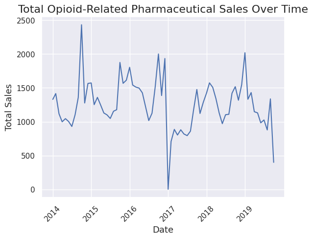

```python
import seaborn as sns
import pandas as pd
import matplotlib.pyplot as plt

# i like the dark theme
sns.set_theme(style="darkgrid")
ax = sns.lineplot(data=pharmaSales_df, x='Date', y='Sum_Opioid_Related_Sales')

# using seaborn's labeling method i labeled them as follows
ax.set_title('Total Opioid-Related Pharmaceutical Sales Over Time', fontsize=16)
ax.set_xlabel('Date', fontsize=13)
ax.set_ylabel('Total Sales', fontsize=13)

# using pandas I made sure the date column was datetime format and then only plotted one tick per year
pharmaSales_df['Date'] = pd.to_datetime(pharmaSales_df['Date'])
ax.set_xticks(pharmaSales_df['Date'][::12])
ax.set_xticklabels(pharmaSales_df['Date'].dt.year[::12], rotation=45)

#if i use matplotlib it prevents extra data from being output
plt.show()
```

## **At first glance its interesting to see the pharmaceutical sales have "peak" seasons and not so good seasons but makes sense when thinking about 'flu seasons'**

### Next I'd like to show the descriptive stats for each of the years this Pharmacy Store has been open.

```python
pharmaSales_df['Year'] = pharmaSales_df['Date'].dt.year
opioid_sales_stats = pharmaSales_df.groupby('Year')['Sum_Opioid_Related_Sales'].describe()
print(opioid_sales_stats)
```

```
      count         mean         std       min         25%        50%  \
Year
2014   12.0  1298.404583  407.414994   930.000  1034.99125  1196.8375
2015   12.0  1342.031667  258.017861  1048.128  1148.59100  1250.7110
2016   12.0  1498.866667  301.668277  1017.192  1346.62700  1504.1385
2017   12.0   901.210750  366.949123     1.000   801.31250   870.5750
2018   12.0  1330.722917  204.568324   971.143  1124.75050  1382.2495
2019   10.0  1168.678600  419.199452   399.280   994.43000  1139.4560

             75%       max
Year
2014  1373.74000  2433.315
2015  1569.10375  1876.335
2016  1607.60250  2001.175
2017  1135.28675  1476.350
2018  1510.26100  1574.434
2019  1336.06300  2020.112
```

# After working the pharmaSales data I would like work the Opiods json file to view total deaths over the years for 6 different areas all while using 2 heatmaps because they're fun and I thought I'd switch it up.

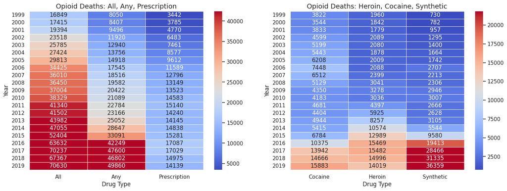

```python
import seaborn as sbrn
import matplotlib.pyplot as plt

# Extract necessary columns for heatmap
opioid_heatmap1_df = opioids_df.pivot_table(index='Year', values=[
  'All','Any','Prescription'])
opioid_heatmap2_df = opioids_df.pivot_table(index='Year', values=[
  'Synthetic','Heroin','Cocaine'])

# I used this subplot method to show two heatmaps of the opioid deaths All, Any, Prescription vs Heroin, Cocain, Synthetic
#https://colab.research.google.com/github/jakevdp/PythonDataScienceHandbook/blob/master/notebooks/04.08-Multiple-Subplots.ipynb
fig, axes = plt.subplots(1, 2, figsize=(18, 6))

# heatmap logic held here and then I use the subplot method I found on the google colab handbook
sbrn.heatmap(opioid_heatmap1_df, cmap='coolwarm', annot=True, fmt=".0f", linewidths=0.5, vmin=opioid_heatmap1_df.min().min(), vmax=opioid_heatmap1_df.max().max() * 0.6, ax=axes[0])
axes[0].set_title('Opioid Deaths: All, Any, Prescription', fontsize=14)
axes[0].set_xlabel('Drug Type')
axes[0].set_ylabel('Year')

sbrn.heatmap(opioid_heatmap2_df, cmap='coolwarm', annot=True, fmt=".0f", linewidths=0.5, vmin=opioid_heatmap2_df.min().min(), vmax=opioid_heatmap2_df.max().max() * 0.6, ax=axes[1])
axes[1].set_title('Opioid Deaths: Heroin, Cocaine, Synthetic', fontsize=14)
axes[1].set_xlabel('Drug Type')
axes[1].set_ylabel('Year')

# using matplotlib plt.show() this should show the heatmap without extra output data from seaborn
plt.show()
```

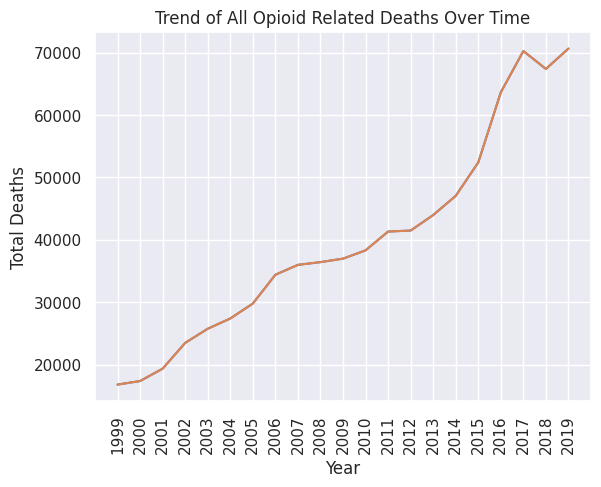

```python
#TODO: I would like to build a total deaths vs total sales graph with both datasets however I need to first build a line graph of total opioid deaths
import seaborn as sbrn
import matplotlib.pyplot as plt

sbrn.lineplot(data=opioids_df, x='Year', y='All')
ax = sbrn.lineplot(data=opioids_df, x='Year', y='All')
ax.set_title('Trend of All Opioid Related Deaths Over Time')
ax.set_xlabel('Year')
ax.set_ylabel('Total Deaths')
ax.set_xticks(opioids_df['Year'].unique())
ax.set_xticklabels(opioids_df['Year'].astype(int), rotation=90)
plt.show()
```

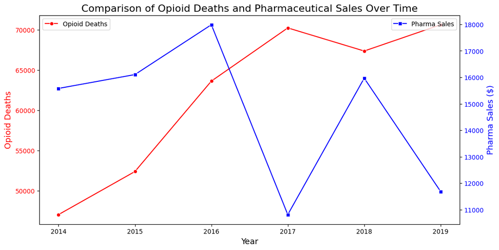

```python
#for this next graph I will need to aggregate pharmaSales by year, as well as opioid deaths by year, i will hopefully create 2 y axis to show the comparative analysis of pharmaceutical sales to opioid deaths over the years
#https://colab.research.google.com/github/amanchadha/aman-ai/blob/master/matplotlib.ipynb I used this notebook for key features I used in this code snippet like marker, as well as ax1 and ax2

#this should convert the date to year
pharmaSales_df['Year'] = pharmaSales_df['Date'].dt.year
#this should hopefully aggregate the data by year
pharma_sales_by_year = pharmaSales_df.groupby('Year')['Sum_Opioid_Related_Sales'].sum().reset_index()

#here I aggregate the 'all' opioid deaths to groupby yeara just like above
opioid_deaths_by_year = opioids_df.groupby('Year')['All'].sum().reset_index()

#I learned how to merge the datasets using this notebook, I figured it would be possible due to SQL and other programs having merge options
# https://colab.research.google.com/github/jakevdp/PythonDataScienceHandbook/blob/master/notebooks/03.07-Merge-and-Join.ipynb
comparison_df = pd.merge(opioid_deaths_by_year, pharma_sales_by_year, on='Year')

# this should create the main figure and subplot allowing the 2 plots within one figure
fig, ax1 = plt.subplots(figsize=(12,6))

# this will handle the opioid deaths on the left side
sbrn.lineplot(data=comparison_df, x='Year', y='All', marker='o', ax=ax1, color='red', label="Opioid Deaths")
ax1.set_ylabel("Opioid Deaths", fontsize=13, color='red')
ax1.tick_params(axis='y', labelcolor='red')

# this should hopefully be the second y axis showing the pharmaSales data
ax2 = ax1.twinx()
sbrn.lineplot(data=comparison_df, x='Year', y='Sum_Opioid_Related_Sales', marker='s', ax=ax2, color='blue', label="Pharma Sales")
ax2.set_ylabel("Pharma Sales ($)", fontsize=13, color='blue')
ax2.tick_params(axis='y', labelcolor='blue')

plt.title("Comparison of Opioid Deaths and Pharmaceutical Sales Over Time", fontsize=16)
ax1.set_xlabel("Year", fontsize=13)
plt.xticks(rotation=45)

# this will allow me to show legends in the top corners
ax1.legend(loc='upper left')
ax2.legend(loc='upper right')

# Show the plot
plt.show()
```